# Attrition R Project

Rajanna Latte

07/08/2020

## Libraries Used

```r
library(tidyverse)
library(data.table)
library(VIM)
library(DT)
library(gridExtra)
library(caret)
library(Metrics)
library(randomForest)
library(pROC)
library(e1071)
library(dtree)
```

```r
library(corrplot)
library(DMwR)
library(tree)
```

## Set working directory

```r
setwd("D:/Imarticus Projects/RProject-Attrition/R Project - Attrition")
```

## Import Data

```r
attrition = fread("Attrition.csv", sep = ",", header = TRUE, stringsAsFactors = T)
```

## Understanding the data

```r
glimpse(attrition)
```

```
## Rows: 1,470
## Columns: 35
## $ Age                      <int> 41, 49, 37, 33, 27, 32, 59, 30, 38, 36, 35...
## $ Attrition                <fct> Yes, No, Yes, No, No, No, No, No, No, No, ...
## $ BusinessTravel           <fct> Travel_Rarely, Travel_Frequently, Travel_R...
## $ DailyRate                <int> 1102, 279, 1373, 1392, 591, 1005, 1324, 13...
## $ Department               <fct> Sales, Research & Development, Research & ...
## $ DistanceFromHome         <int> 1, 8, 2, 3, 2, 2, 3, 24, 23, 27, 16, 15, 2...
## $ Education                <int> 2, 1, 2, 4, 1, 2, 3, 1, 3, 3, 3, 2, 1, 2, ...
## $ EducationField           <fct> Life Sciences, Life Sciences, Other, Life ...
## $ EmployeeCount            <int> 1, 1, 1, 1, 1, 1, 1, 1, 1, 1, 1, 1, 1, 1, ...
## $ EmployeeNumber           <int> 1, 2, 4, 5, 7, 8, 10, 11, 12, 13, 14, 15, ...
## $ EnvironmentSatisfaction  <int> 2, 3, 4, 4, 1, 4, 3, 4, 4, 3, 1, 4, 1, 2, ...
## $ Gender                   <fct> Female, Male, Male, Female, Male, Male, Fe...
## $ HourlyRate               <int> 94, 61, 92, 56, 40, 79, 81, 67, 44, 94, 84...
```

[output cut: 22 more lines]

```r
summary(attrition)
```

```
##       Age        Attrition            BusinessTravel   DailyRate
##  Min.   :18.00   No :1233   Non-Travel       : 150   Min.   : 102.0
##  1st Qu.:30.00   Yes: 237   Travel_Frequently: 277   1st Qu.: 465.0
##  Median :36.00              Travel_Rarely    :1043   Median : 802.0
##  Mean   :36.92                                       Mean   : 802.5
##  3rd Qu.:43.00                                       3rd Qu.:1157.0
##  Max.   :60.00                                       Max.   :1499.0
##
##                   Department  DistanceFromHome   Education
##  Human Resources       : 63   Min.   : 1.000   Min.   :1.000
##  Research & Development:961   1st Qu.: 2.000   1st Qu.:2.000
##  Sales                 :446   Median : 7.000   Median :3.000
##                               Mean   : 9.193   Mean   :2.913
##                               3rd Qu.:14.000   3rd Qu.:4.000
##                               Max.   :29.000   Max.   :5.000
##
##           EducationField EmployeeCount EmployeeNumber   EnvironmentSatisfaction
##  Human Resources : 27    Min.   :1     Min.   :   1.0   Min.   :1.000
##  Life Sciences   :606    1st Qu.:1     1st Qu.: 491.2   1st Qu.:2.000
##  Marketing       :159    Median :1     Median :1020.5   Median :3.000
##  Medical         :464    Mean   :1     Mean   :1024.9   Mean   :2.722
##  Other           : 82    3rd Qu.:1     3rd Qu.:1555.8   3rd Qu.:4.000
##  Technical Degree:132    Max.   :1     Max.   :2068.0   Max.   :4.000
##
##     Gender      HourlyRate     JobInvolvement    JobLevel
##  Female:588   Min.   : 30.00   Min.   :1.00   Min.   :1.000
##  Male  :882   1st Qu.: 48.00   1st Qu.:2.00   1st Qu.:1.000
##               Median : 66.00   Median :3.00   Median :2.000
##               Mean   : 65.89   Mean   :2.73   Mean   :2.064
##               3rd Qu.: 83.75   3rd Qu.:3.00   3rd Qu.:3.000
##               Max.   :100.00   Max.   :4.00   Max.   :5.000
##
##                       JobRole    JobSatisfaction  MaritalStatus MonthlyIncome
##  Sales Executive          :326   Min.   :1.000   Divorced:327   Min.   : 1009
##  Research Scientist       :292   1st Qu.:2.000   Married :673   1st Qu.: 2911
##  Laboratory Technician    :259   Median :3.000   Single  :470   Median : 4919
##  Manufacturing Director   :145   Mean   :2.729                  Mean   : 6503
##  Healthcare Representative:131   3rd Qu.:4.000                  3rd Qu.: 8379
##  Manager                  :102   Max.   :4.000                  Max.   :19999
##  (Other)                  :215
```

[output cut: 17 more lines]

```
##  Min.   : 0.00     Min.   :0.000         Min.   :1.000   Min.   : 0.000
##  1st Qu.: 6.00     1st Qu.:2.000         1st Qu.:2.000   1st Qu.: 3.000
##  Median :10.00     Median :3.000         Median :3.000   Median : 5.000
##  Mean   :11.28     Mean   :2.799         Mean   :2.761   Mean   : 7.008
##  3rd Qu.:15.00     3rd Qu.:3.000         3rd Qu.:3.000   3rd Qu.: 9.000
##  Max.   :40.00     Max.   :6.000         Max.   :4.000   Max.   :40.000
##
##  YearsInCurrentRole YearsSinceLastPromotion YearsWithCurrManager
##  Min.   : 0.000     Min.   : 0.000          Min.   : 0.000
##  1st Qu.: 2.000     1st Qu.: 0.000          1st Qu.: 2.000
##  Median : 3.000     Median : 1.000          Median : 3.000
##  Mean   : 4.229     Mean   : 2.188          Mean   : 4.123
##  3rd Qu.: 7.000     3rd Qu.: 3.000          3rd Qu.: 7.000
##  Max.   :18.000     Max.   :15.000          Max.   :17.000
##
```

```r
colnames(attrition)
```

```
##  [1] "Age"                      "Attrition"
##  [3] "BusinessTravel"           "DailyRate"
##  [5] "Department"               "DistanceFromHome"
##  [7] "Education"                "EducationField"
##  [9] "EmployeeCount"            "EmployeeNumber"
## [11] "EnvironmentSatisfaction"  "Gender"
## [13] "HourlyRate"               "JobInvolvement"
## [15] "JobLevel"                 "JobRole"
## [17] "JobSatisfaction"          "MaritalStatus"
## [19] "MonthlyIncome"            "MonthlyRate"
## [21] "NumCompaniesWorked"       "Over18"
## [23] "OverTime"                 "PercentSalaryHike"
## [25] "PerformanceRating"        "RelationshipSatisfaction"
## [27] "StandardHours"            "StockOptionLevel"
## [29] "TotalWorkingYears"        "TrainingTimesLastYear"
## [31] "WorkLifeBalance"          "YearsAtCompany"
## [33] "YearsInCurrentRole"       "YearsSinceLastPromotion"
## [35] "YearsWithCurrManager"
```

In Attrition dataset, there are 1470 observation with 35 variables.Column Attrition has 1233 ‘NO’ and 237 ‘Yes’ that shows the unbalance data. We have to pay attention to the unbalance class algorithm problems.

Employee Count is equal 1 for all observation which can not generate useful value for the analysis. Hence, removing the Employee Count.

All employees are over 18. Hence, removing the column Over18, also the decision for Standard Hours is same.

Employee Number is a variable for identifying the specific employee.If we have more information about employee and the structure of the employee number, then we can extract some new features. But now it is not possible and we have to remove it from our data set.

More and more, we have to investigate that, how the company objective factors influence in attrition employees, and what kind of working environment most will cause employees attrition.

# Check Missing Values

```r
colSums(is.na(attrition))
```

```
##                      Age                Attrition           BusinessTravel
##                        0                        0                        0
##                DailyRate               Department         DistanceFromHome
##                        0                        0                        0
##                Education           EducationField            EmployeeCount
##                        0                        0                        0
##           EmployeeNumber  EnvironmentSatisfaction                   Gender
##                        0                        0                        0
##               HourlyRate           JobInvolvement                 JobLevel
##                        0                        0                        0
##                  JobRole          JobSatisfaction            MaritalStatus
##                        0                        0                        0
##            MonthlyIncome              MonthlyRate       NumCompaniesWorked
##                        0                        0                        0
##                   Over18                 OverTime        PercentSalaryHike
##                        0                        0                        0
##        PerformanceRating RelationshipSatisfaction            StandardHours
##                        0                        0                        0
##         StockOptionLevel        TotalWorkingYears    TrainingTimesLastYear
##                        0                        0                        0
##          WorkLifeBalance           YearsAtCompany       YearsInCurrentRole
##                        0                        0                        0
##  YearsSinceLastPromotion     YearsWithCurrManager
##                        0                        0
```

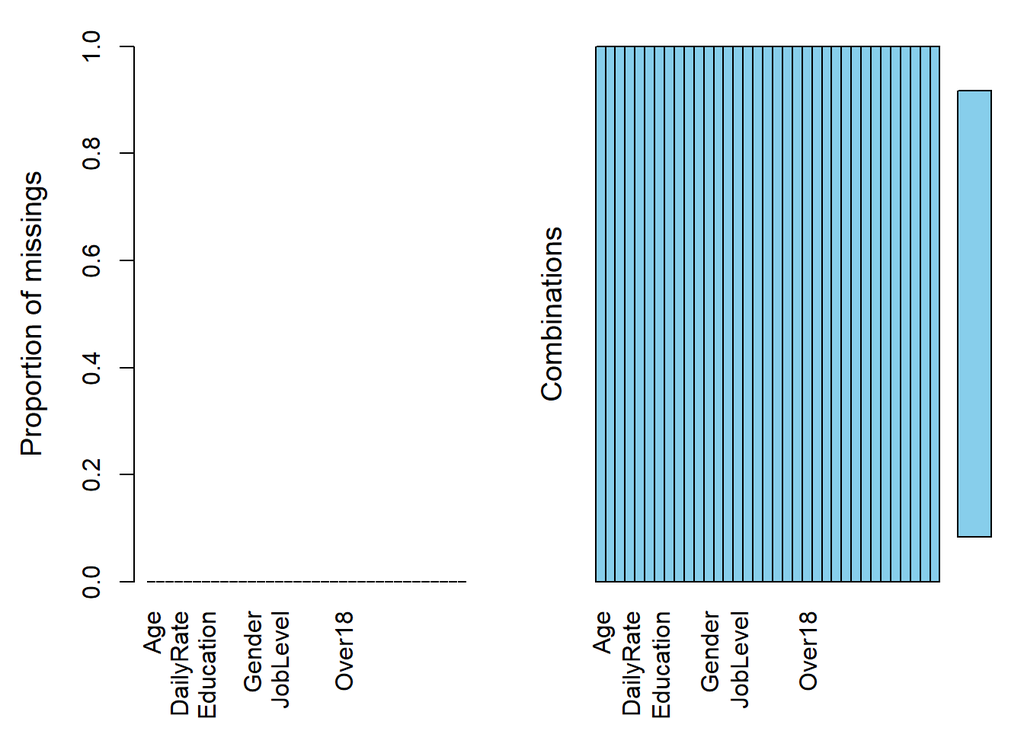

```r
VIM::aggr(attrition)
```

#Must say, we are so lucky that this dataset has no missing values.

Remove non value attributes.These variables can not play significant role because they are same for all records. Also, EmployeeNumber can be accepted as an indicator for the time of join to the company which can be used for new feature generation,But we do not have any meta data about it, then, lets remove it.

```r
attrition$EmployeeNumber <- NULL
attrition$StandardHours <- NULL
attrition$Over18 <- NULL
attrition$EmployeeCount <- NULL

cat("Data Set has ",dim(attrition)[1], " Rows and ", dim(attrition)[2], " Columns" )
```

```
## Data Set has  1470  Rows and  31  Columns
```

## check for duplicated Record

```r
sum (is.na(duplicated(attrition)))
```

```
## [1] 0
```

There are some variables that are categorical, but in the data set are integer. We have to change them to categorical. also, we do not need any dummy variable creation, where some machine learning algorithms like RF, XGBoost etc. can use categorical variables.

For other algorithms like NN we have to change categorical variable more than two level to dummy variable Variable with two level (Binary) can be change to number very easy.

```r
attrition$Education <- as.factor(attrition$Education)
attrition$EnvironmentSatisfaction <- as.factor(attrition$EnvironmentSatisfaction)
attrition$JobInvolvement <- as.factor(attrition$JobInvolvement)
attrition$JobLevel <- as.factor(attrition$JobLevel)
attrition$JobSatisfaction <- as.factor(attrition$JobSatisfaction)
attrition$PerformanceRating <- as.factor(attrition$PerformanceRating)
attrition$RelationshipSatisfaction <- as.factor(attrition$RelationshipSatisfaction)
attrition$StockOptionLevel <- as.factor(attrition$StockOptionLevel)
attrition$WorkLifeBalance <- as.factor(attrition$WorkLifeBalance)
```

## Vizualization

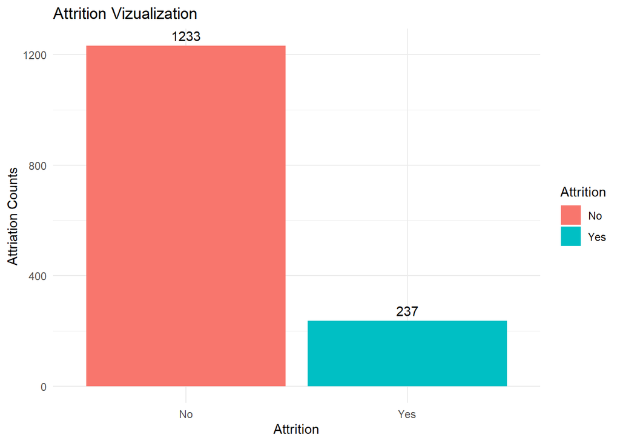

```r
attrition %>%
        group_by(Attrition) %>%
        tally() %>%
        ggplot(aes(x = Attrition, y = n,fill=Attrition)) +
        geom_bar(stat = "identity") +
        theme_minimal()+
        labs(x="Attrition", y="Attriation Counts")+
        ggtitle("Attrition Vizualization")+
        geom_text(aes(label = n), vjust = -0.5, position = position_dodge(0.9))
```

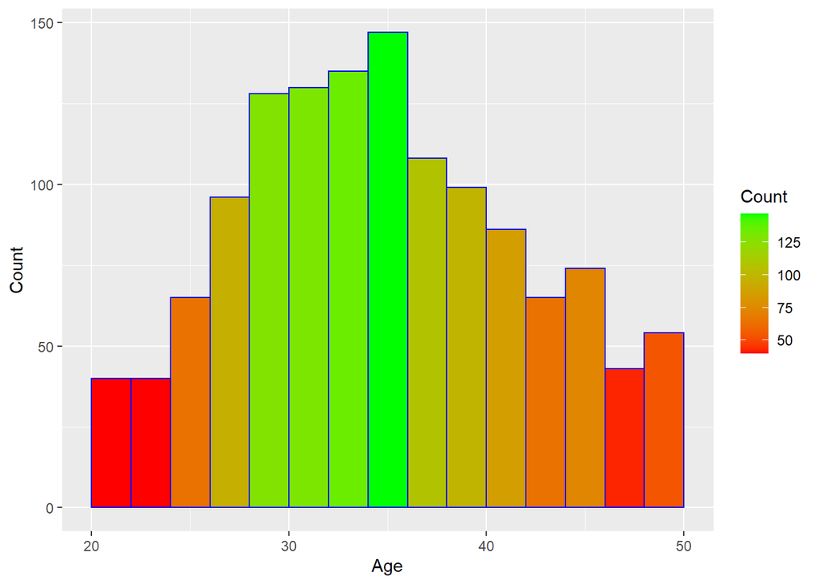

```r
ggplot(data=attrition, aes(attrition$Age)) +
        geom_histogram(breaks=seq(20, 50, by=2),
                       col="blue",
                       aes(fill=..count..))+
        labs(x="Age", y="Count")+
        scale_fill_gradient("Count", low="red", high="green")
```

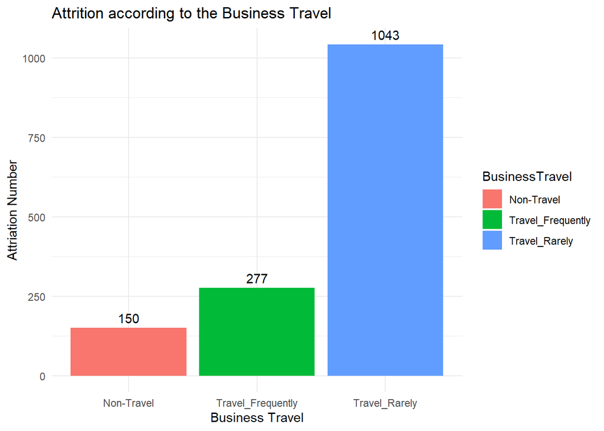

```r
attrition %>%
        group_by(BusinessTravel) %>%
        tally() %>%
        ggplot(aes(x = BusinessTravel, y = n,fill=BusinessTravel)) +
        geom_bar(stat = "identity") +
        theme_minimal()+
        labs(x="Business Travel", y="Attriation Number")+
        ggtitle("Attrition according to the Business Travel")+
        geom_text(aes(label = n), vjust = -0.5, position = position_dodge(0.9))
```

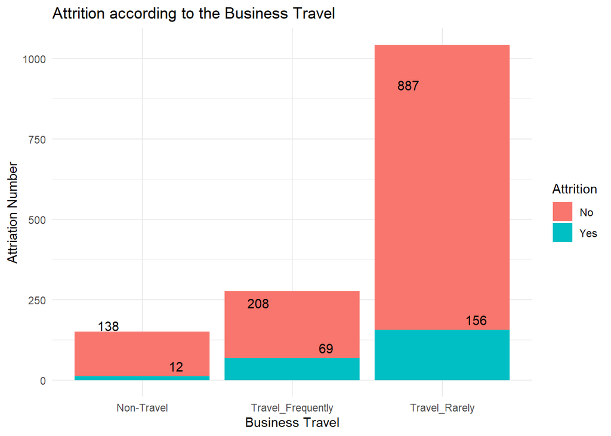

```r
attrition %>%
        group_by(BusinessTravel, Attrition) %>%
        tally() %>%
        ggplot(aes(x = BusinessTravel, y = n,fill=Attrition)) +
        geom_bar(stat = "identity") +
        theme_minimal()+
        labs(x="Business Travel", y="Attriation Number")+
        ggtitle("Attrition according to the Business Travel")+
        geom_text(aes(label = n), vjust = -0.5, position = position_dodge(0.9))
```

Here is the distribution of the data according to the Business Travel situation. more than 70% of employees travel rarely where just 10 % of them has no travel.

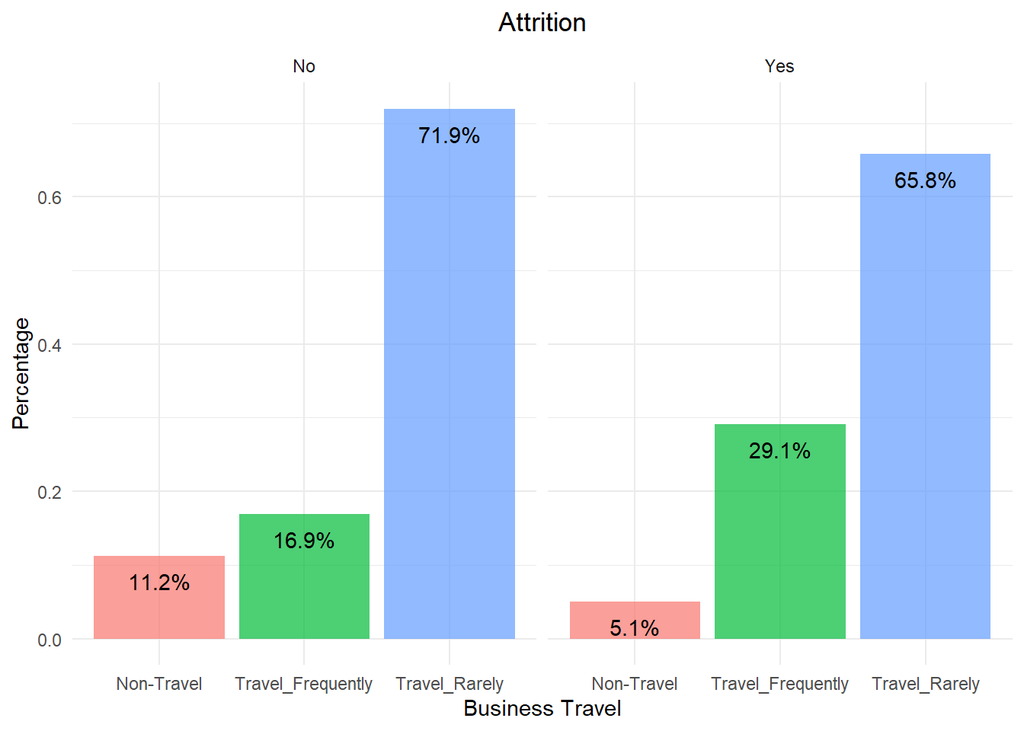

```r
attrition %>%
        ggplot(aes(x = BusinessTravel, group = Attrition)) +
        geom_bar(aes(y = ..prop.., fill = factor(..x..)),
                 stat="count",
                 alpha = 0.7) +
        geom_text(aes(label = scales::percent(..prop..), y = ..prop.. ),
                  stat= "count",
                  vjust = 2) +
        labs(y = "Percentage", fill= "business Travel") +
        facet_grid(~Attrition) +
        theme_minimal()+
        theme(legend.position = "none", plot.title = element_text(hjust = 0.5)) +
        labs(x="Business Travel", y="Percentage")+
        ggtitle("Attrition")
```

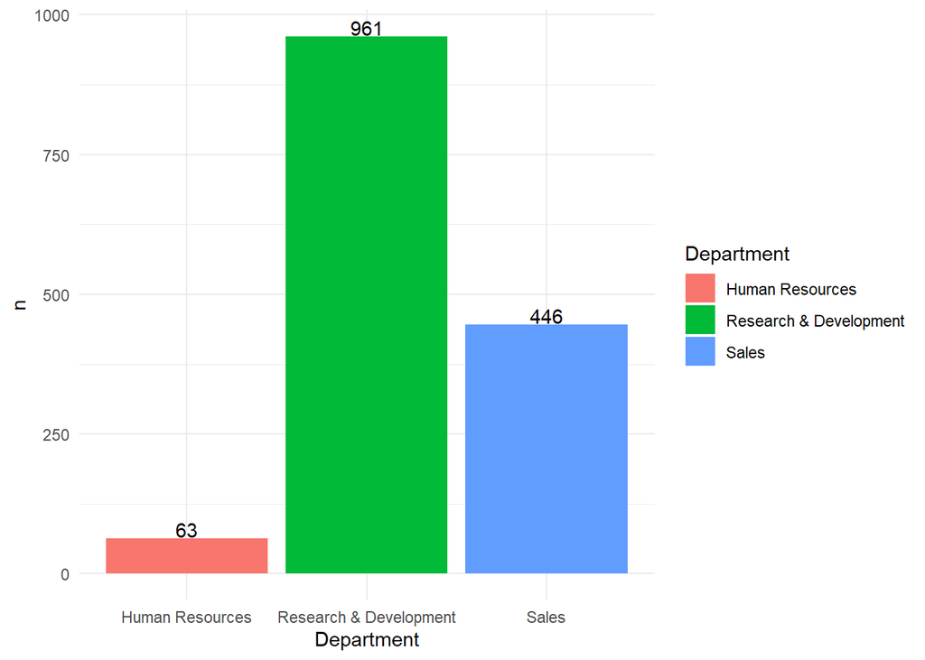

```r
attrition %>%
        group_by(Department) %>%
        tally() %>%
        ggplot(aes(x = Department, y = n,fill=Department)) +
        geom_bar(stat = "identity") +
        theme_minimal()+
        geom_text(aes(label = n), vjust = -0.1, position = position_dodge(0.9))
```

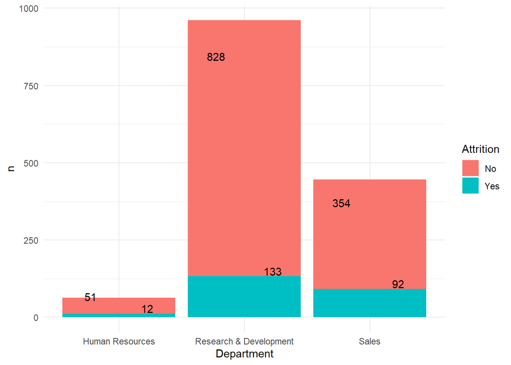

```r
attrition %>%
        group_by(Department, Attrition) %>%
        tally() %>%
        ggplot(aes(x = Department, y = n,fill=Attrition)) +
        geom_bar(stat = "identity") +
        theme_minimal()+
        geom_text(aes(label = n), vjust = -0.1, position = position_dodge(0.9))
```

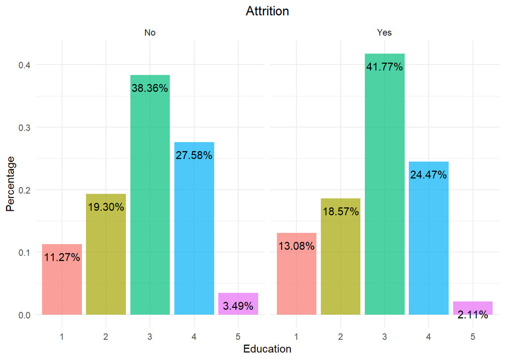

```r
attrition %>%
        ggplot(aes(x = Education, group = Attrition)) +
        geom_bar(aes(y = ..prop.., fill = factor(..x..)),
                 stat="count",
                 alpha = 0.7) +
        geom_text(aes(label = scales::percent(..prop..), y = ..prop.. ),
                  stat= "count",
                  vjust = 2) +
        labs(y = "Percentage", fill= "Education") +
        facet_grid(~Attrition) +
        theme_minimal()+
        theme(legend.position = "none", plot.title = element_text(hjust = 0.5)) +
        ggtitle("Attrition")
```

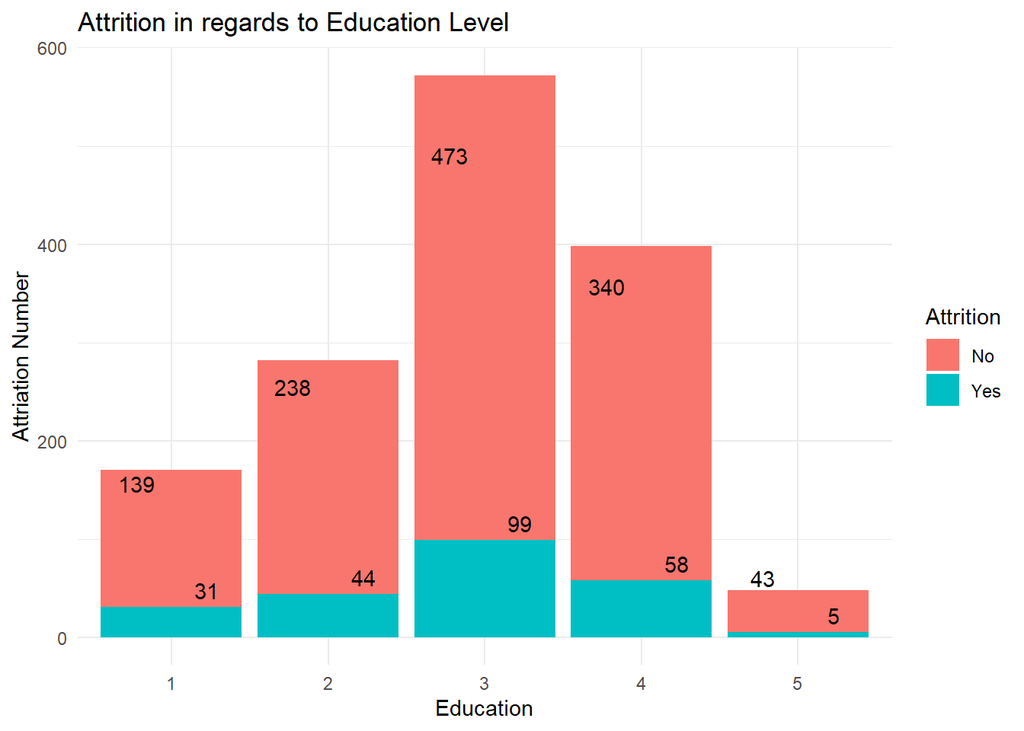

```r
attrition %>%
        group_by(Education, Attrition) %>%
        tally() %>%
        ggplot(aes(x = Education, y = n,fill=Attrition)) +
        geom_bar(stat = "identity") +
        theme_minimal()+
        geom_text(aes(label = n), vjust = -0.5, position = position_dodge(0.9))+
        labs(x="Education", y="Attriation Number")+
        ggtitle("Attrition in regards to Education Level")
```

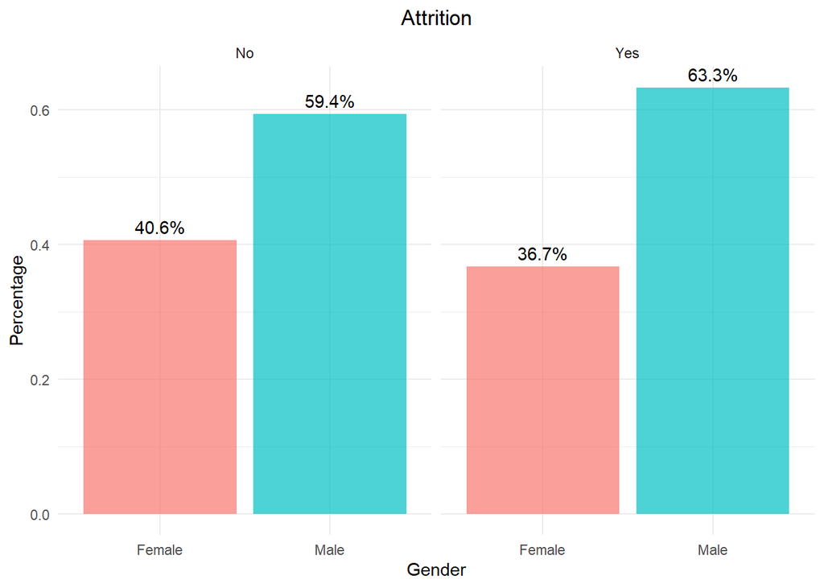

```r
attrition %>%
        ggplot(aes(x = Gender, group = Attrition)) +
        geom_bar(aes(y = ..prop.., fill = factor(..x..)),
                 stat="count",
                 alpha = 0.7) +
        geom_text(aes(label = scales::percent(..prop..), y = ..prop.. ),
                  stat= "count",
                  vjust = -.5) +
        labs(y = "Percentage", fill= "Gender") +
        facet_grid(~Attrition) +
        theme_minimal()+
        theme(legend.position = "none", plot.title = element_text(hjust = 0.5)) +
        ggtitle("Attrition")
```

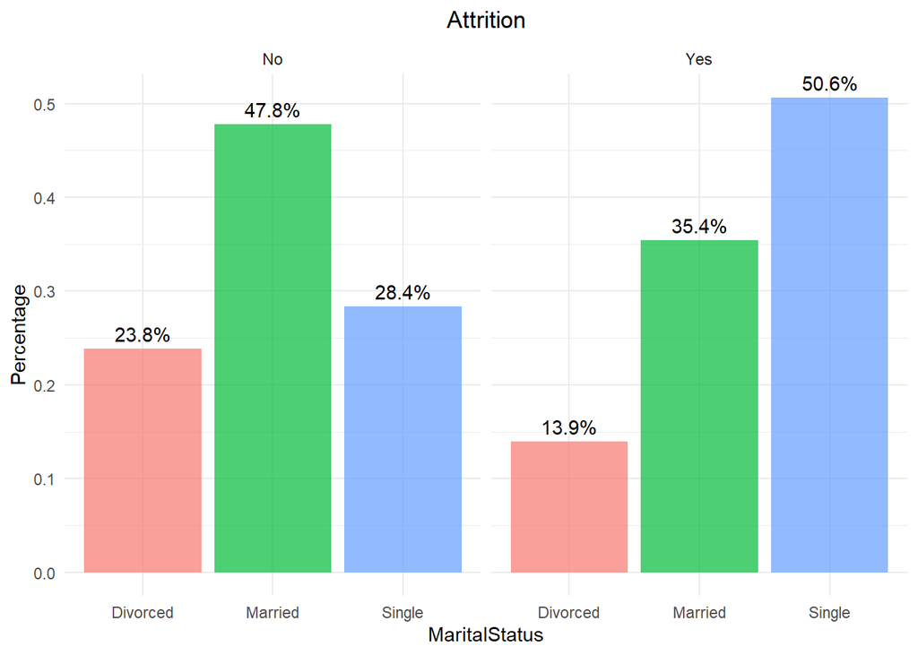

```r
attrition %>%
        ggplot(aes(x = MaritalStatus, group = Attrition)) +
        geom_bar(aes(y = ..prop.., fill = factor(..x..)),
                 stat="count",
                 alpha = 0.7) +
        geom_text(aes(label = scales::percent(..prop..), y = ..prop.. ),
                  stat= "count",
                  vjust = -.5) +
        labs(y = "Percentage", fill= "MaritalStatus") +
        facet_grid(~Attrition) +
        theme_minimal()+
        theme(legend.position = "none", plot.title = element_text(hjust = 0.5)) +
        ggtitle("Attrition")
```

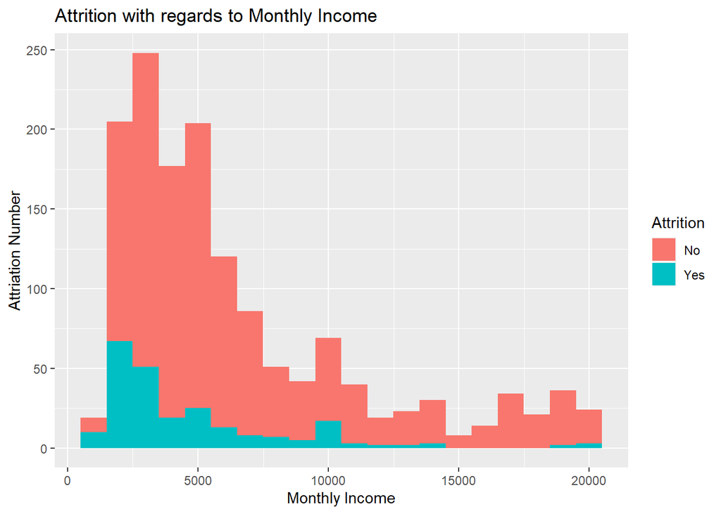

```r
attrition %>%
        ggplot(mapping = aes(x = MonthlyIncome)) +
        geom_histogram(aes(fill = Attrition), bins=20)+
        labs(x="Monthly Income", y="Attriation Number")+
        ggtitle("Attrition with regards to Monthly Income")
```

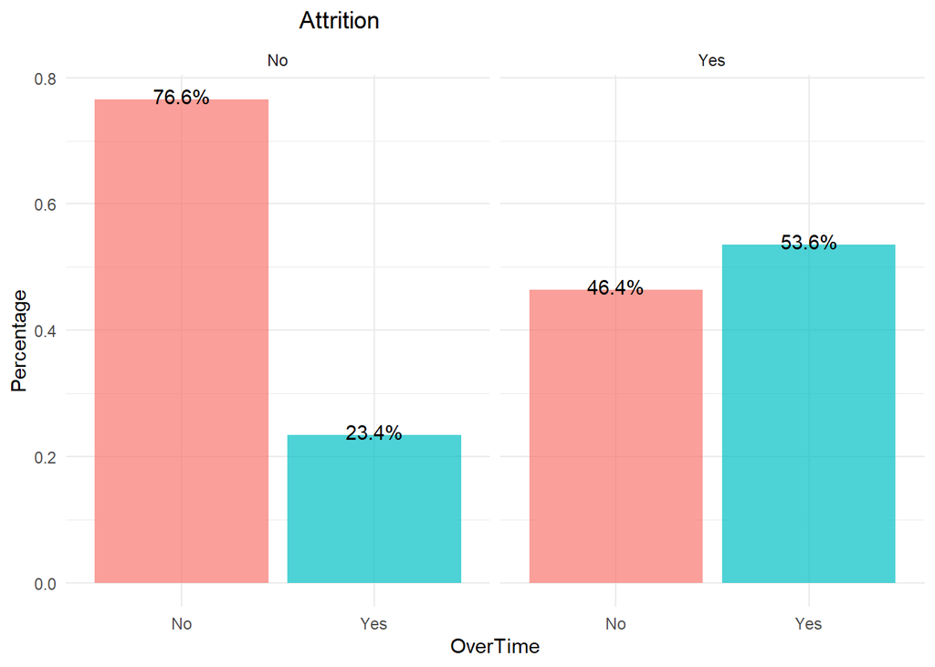

```r
attrition %>%
        ggplot(aes(x = OverTime, group = Attrition)) +
        geom_bar(aes(y = ..prop.., fill = factor(..x..)),
                 stat="count",
                 alpha = 0.7) +
        geom_text(aes(label = scales::percent(..prop..), y = ..prop.. ),
                  stat= "count",
                  vjust = 0.3) +
        labs(y = "Percentage", fill= "OverTime") +
        facet_grid(~Attrition) +
        theme_minimal()+
        theme(legend.position = "none", plot.title = element_text(hjust = 0.3)) +
        ggtitle("Attrition")
```

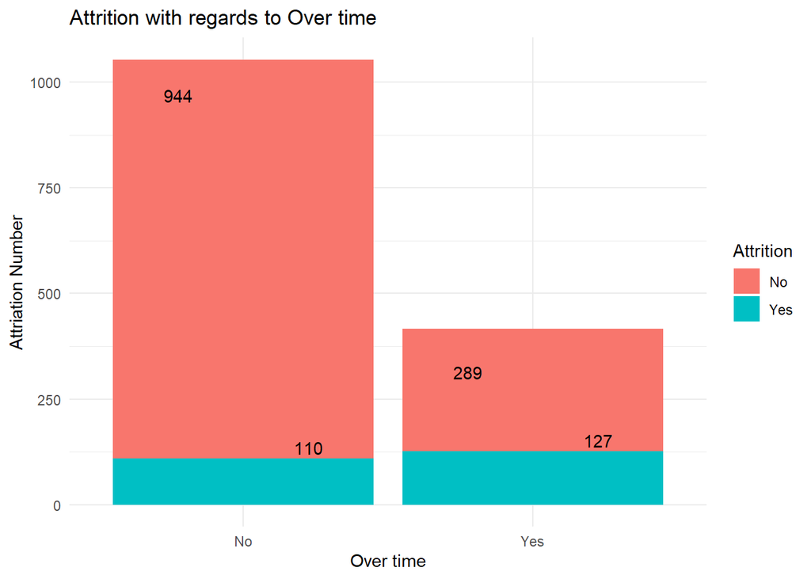

```r
attrition %>%
        group_by(OverTime, Attrition) %>%
        tally() %>%
        ggplot(aes(x = OverTime, y = n,fill=Attrition)) +
        geom_bar(stat = "identity") +
        theme_minimal()+
        geom_text(aes(label = n), vjust = -0.3, position = position_dodge(0.9))+
        labs(x="Over time", y="Attriation Number")+
        ggtitle("Attrition with regards to Over time")
```

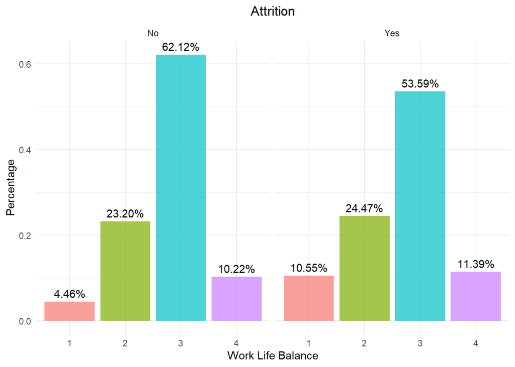

```r
attrition%>%
        ggplot(aes(x = WorkLifeBalance, group = Attrition)) +
        geom_bar(aes(y = ..prop.., fill = factor(..x..)),
                 stat="count",
                 alpha = 0.7) +
        geom_text(aes(label = scales::percent(..prop..), y = ..prop.. ),
                  stat= "count",
                  vjust = -.5) +
        labs(x = "Work Life Balance",y = "Percentage", fill= "WorkLifeBalance") +
        facet_grid(~Attrition) +
        theme_minimal()+
        theme(legend.position = "none", plot.title = element_text(hjust = 0.5)) +
        ggtitle("Attrition")
```

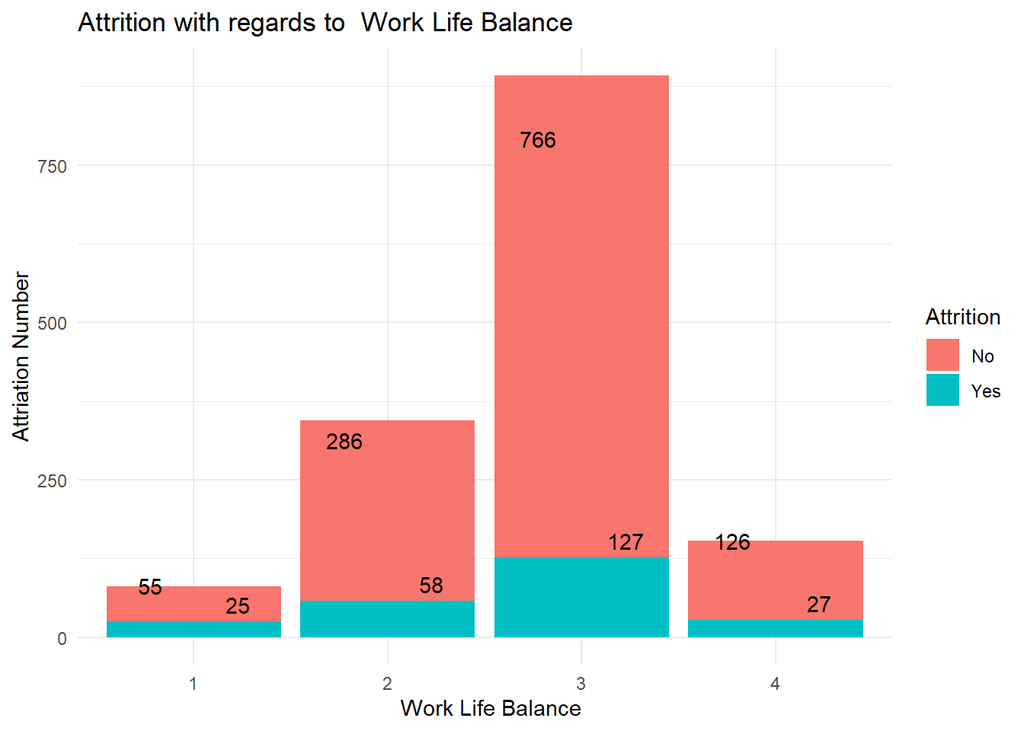

```r
attrition %>%
        group_by(WorkLifeBalance, Attrition) %>%
        tally() %>%
        ggplot(aes(x = WorkLifeBalance, y = n,fill=Attrition)) +
        geom_bar(stat = "identity") +
        theme_minimal()+
        geom_text(aes(label = n), vjust = -0.5, position = position_dodge(0.9))+
        labs(x="  Work Life Balance", y="Attriation Number")+
        ggtitle("Attrition with regards to  Work Life Balance")
```

## Using Raw data by RF

At the first Stage we use RF for getting some information about the prediction split Data to Train and Test

```r
rfData <- attrition
set.seed(123)
indexes = sample(1:nrow(rfData), size=0.8*nrow(rfData))
RFRaw.train.Data <- rfData[indexes,]
RFRaw.test.Data <- rfData[-indexes,]
```

## Model Building

```r
Raw.rf.model <- randomForest(Attrition~.,RFRaw.train.Data, importance=TRUE,ntree=1000)
```

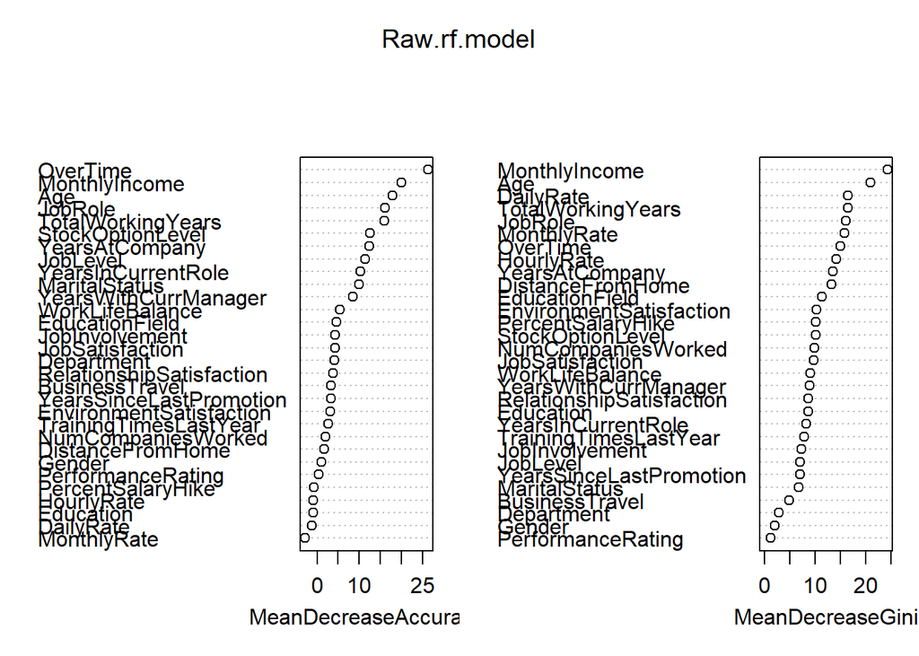

```r
varImpPlot(Raw.rf.model)
```

As we see here, Over time, Age, MonthlyIncome, Jobrole and TotalWorkingYears are top five variables.

```r
Raw.rf.prd <- predict(Raw.rf.model, newdata = RFRaw.test.Data)
confusionMatrix(RFRaw.test.Data$Attrition, Raw.rf.prd)
```

```
## Confusion Matrix and Statistics
##
##           Reference
## Prediction  No Yes
##        No  244   2
##        Yes  40   8
##
##                Accuracy : 0.8571
##                  95% CI : (0.8118, 0.8951)
##     No Information Rate : 0.966
##     P-Value [Acc > NIR] : 1
##
##                   Kappa : 0.2327
##
##  Mcnemar's Test P-Value : 1.135e-08
##
##             Sensitivity : 0.8592
##             Specificity : 0.8000
##          Pos Pred Value : 0.9919
##          Neg Pred Value : 0.1667
##              Prevalence : 0.9660
##          Detection Rate : 0.8299
##    Detection Prevalence : 0.8367
##       Balanced Accuracy : 0.8296
##
##        'Positive' Class : No
##
```

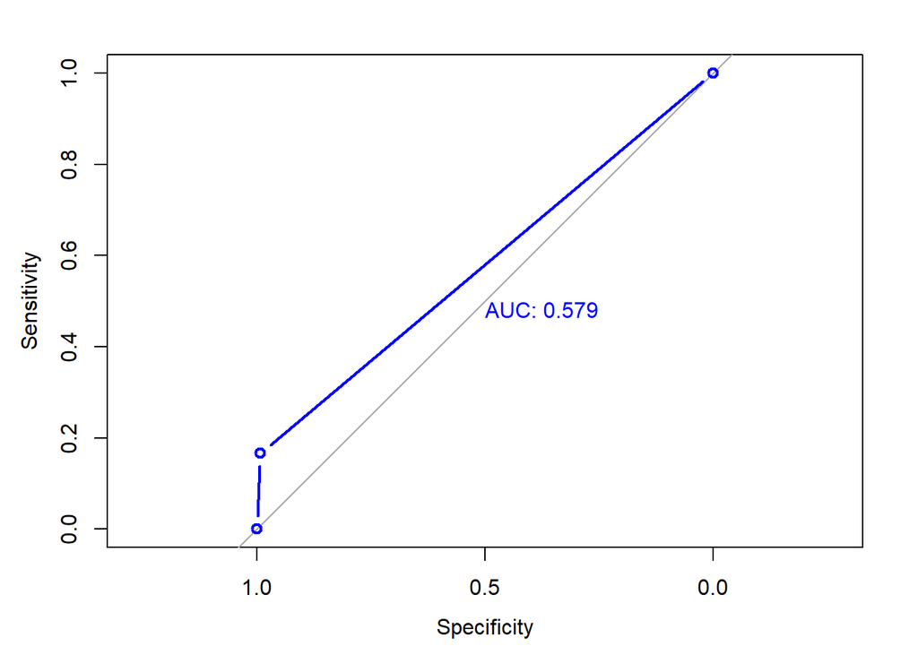

```r
Raw.rf.plot<- plot.roc(as.numeric(RFRaw.test.Data$Attrition), as.numeric(Raw.rf.prd),lwd=2, type="b",print.auc=TRUE,col ="blue")
```

## Feature Engineering

Making Age Group 18-24 = Young , 25-54=Middle-Age , 54-120= Adult

```r
attrition$AgeGroup <- as.factor(
        ifelse(attrition$Age<=24,"Young", ifelse(
        attrition$Age<=54,"Middle-Age","Adult"
        ))
)
table(attrition$AgeGroup)
```

```
##
##      Adult Middle-Age      Young
##         69       1304         97
```

##### Total Satisfaction the total of the satisfaction from Job, Environment, etc.

```r
attrition$TotlaSatisfaction <-
        as.numeric(attrition$EnvironmentSatisfaction)+
        as.numeric(attrition$JobInvolvement)+
        as.numeric(attrition$JobSatisfaction)+
        as.numeric(attrition$RelationshipSatisfaction)+
        as.numeric(attrition$WorkLifeBalance)

summary(attrition$TotlaSatisfaction)
```

```
##    Min. 1st Qu.  Median    Mean 3rd Qu.    Max.
##    6.00   12.00   14.00   13.65   15.00   20.00
```

Study Years for getting Education Level certificate

```r
table(attrition$Education)
```

```
##
##   1   2   3   4   5
## 170 282 572 398  48
```

```r
attrition$YearsEducation <-  ifelse(attrition$Education==1,10,ifelse(attrition$Education==2,12,
        ifelse(attrition$Education==3,16,ifelse(attrition$Education==4,18,22))))

table(attrition$YearsEducation)
```

```
##
##  10  12  16  18  22
## 170 282 572 398  48
```

Less or more than average Monthly Income We calculate the average income and generate the level of income(High or Low)

```r
attrition$IncomeLevel <- as.factor(
        ifelse(attrition$MonthlyIncome<ave(attrition$MonthlyIncome),"Low","High")
)
table(attrition$IncomeLevel)
```

```
##
## High  Low
##  493  977
```

## Let’s see the Correlation Matrix of Data

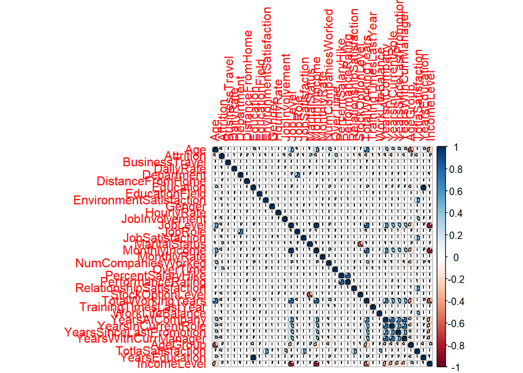

```r
corrplot(cor(sapply(attrition,as.integer)),method = "pie")
```

## New Random Forest

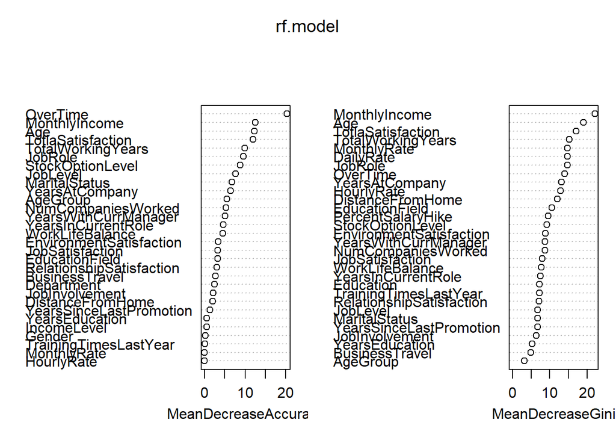

```r
rfData <- attrition
set.seed(123)
indexes = sample(1:nrow(rfData), size=0.8*nrow(rfData))
RFtrain.Data <- rfData[indexes,]
RFtest.Data <- rfData[-indexes,]

rf.model <- randomForest(Attrition~.,RFtrain.Data, importance=TRUE,ntree=500)
varImpPlot(rf.model)
```

Here we see: OverTime, TotalSatisfaction (Generated Attr.), MonthlyIncome, Age and TotalWorkingYears are top five variables.

```r
rf.prd <- predict(rf.model, newdata = RFtest.Data)
confusionMatrix(RFtest.Data$Attrition, rf.prd)
```

```
## Confusion Matrix and Statistics
##
##           Reference
## Prediction  No Yes
##        No  244   2
##        Yes  39   9
##
##                Accuracy : 0.8605
##                  95% CI : (0.8156, 0.898)
##     No Information Rate : 0.9626
##     P-Value [Acc > NIR] : 1
##
##                   Kappa : 0.26
##
##  Mcnemar's Test P-Value : 1.885e-08
##
##             Sensitivity : 0.8622
##             Specificity : 0.8182
##          Pos Pred Value : 0.9919
##          Neg Pred Value : 0.1875
##              Prevalence : 0.9626
##          Detection Rate : 0.8299
##    Detection Prevalence : 0.8367
##       Balanced Accuracy : 0.8402
##
##        'Positive' Class : No
##
```

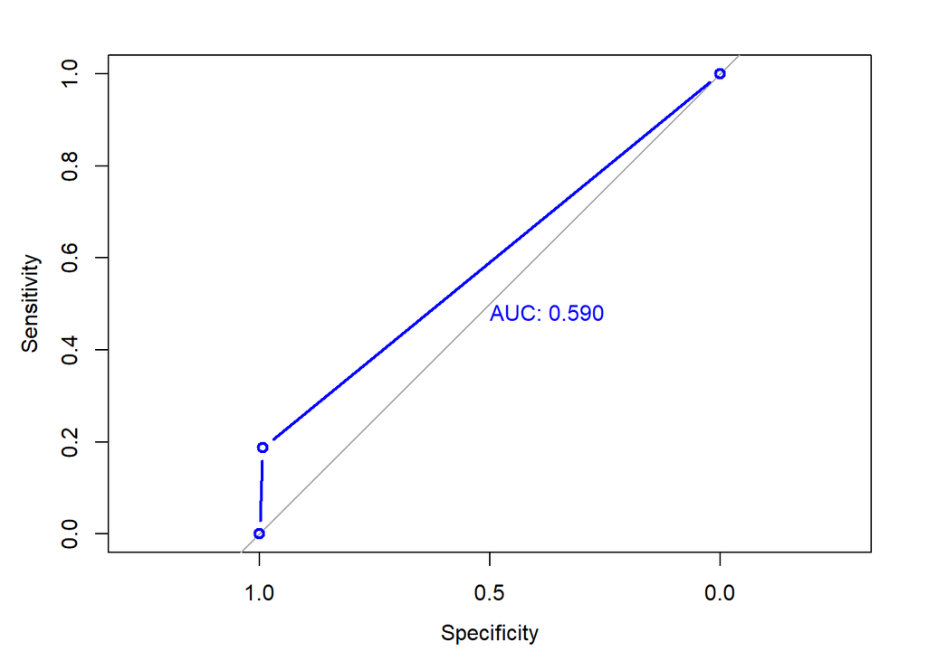

```r
rf.Plot<- plot.roc (as.numeric(RFtest.Data$Attrition), as.numeric(rf.prd),lwd=2, type="b", print.auc=TRUE,col ="blue")
```

It is better than FR algorithm with raw data. TotalSatisfaction is high important attribute.

## Using Support Vector Machine

```r
svmData <- attrition
set.seed(123)
indexes = sample(1:nrow(svmData), size=0.8*nrow(svmData))
SVMtrain.Data <- svmData[indexes,]
SVMtest.Data <- svmData[-indexes,]
tuned <- tune(svm,factor(Attrition)~.,data = SVMtrain.Data)
svm.model <- svm(SVMtrain.Data$Attrition~., data=SVMtrain.Data
                 ,type="C-classification", gamma=tuned$best.model$gamma
                 ,cost=tuned$best.model$cost
                 ,kernel="radial")
svm.prd <- predict(svm.model,newdata=SVMtest.Data)
confusionMatrix(svm.prd,SVMtest.Data$Attrition)
```

```
## Confusion Matrix and Statistics
##
##           Reference
## Prediction  No Yes
##        No  246  44
##        Yes   0   4
##
##                Accuracy : 0.8503
##                  95% CI : (0.8043, 0.8891)
##     No Information Rate : 0.8367
##     P-Value [Acc > NIR] : 0.2947
##
##                   Kappa : 0.132
##
##  Mcnemar's Test P-Value : 9.022e-11
##
##             Sensitivity : 1.00000
##             Specificity : 0.08333
##          Pos Pred Value : 0.84828
##          Neg Pred Value : 1.00000
##              Prevalence : 0.83673
##          Detection Rate : 0.83673
##    Detection Prevalence : 0.98639
##       Balanced Accuracy : 0.54167
##
##        'Positive' Class : No
##
```

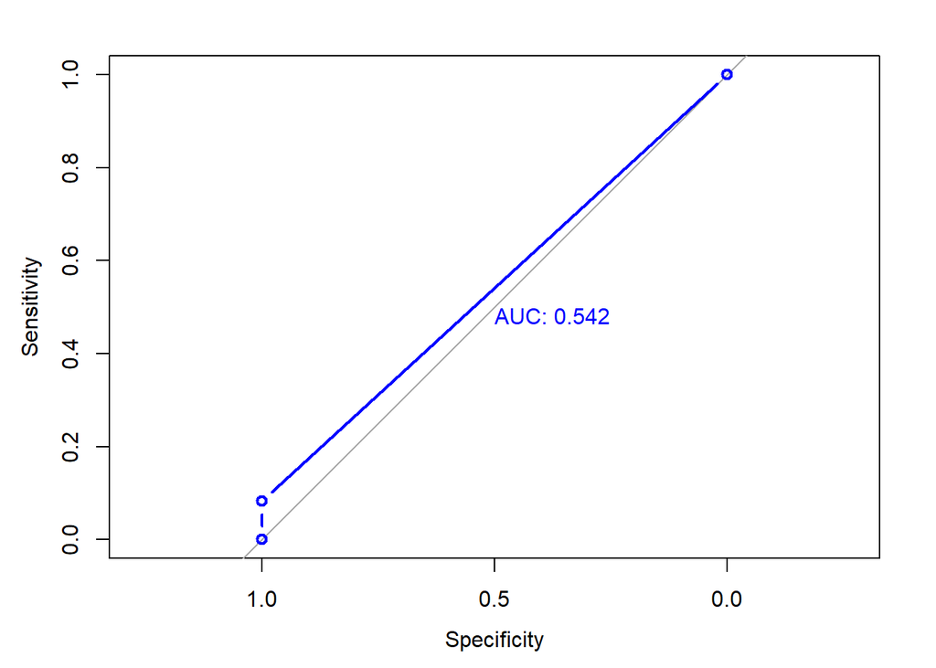

```r
svm.plot <-plot.roc (as.numeric(SVMtest.Data$Attrition), as.numeric(svm.prd),lwd=2, type="b", print.auc=TRUE,col ="blue")
```

as we see, in compare to RF, Accuracy is lower to 0.8503 and AUC to 0.542 which is not better than RF. And there is no False Negative! and a lot of False Positive!

## Decision Tree

Here Dtree will be investigated and compared to other approaches. DTree selected because it is a very good algorithm for interpretion for non-technical like HR.

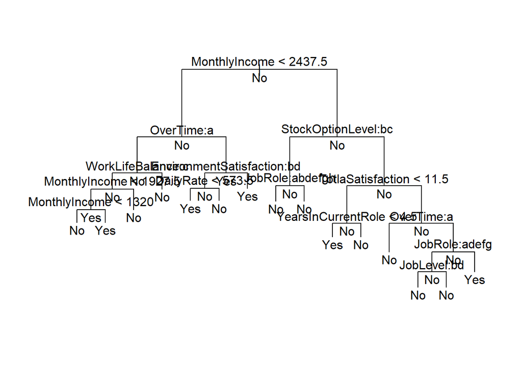

```r
DtData <- attrition
set.seed(123)
indexes = sample(1:nrow(DtData), size=0.8*nrow(DtData))
DTtrain.Data <- DtData[indexes,]
DTtest.Data <- DtData[-indexes,]

dtree.model <- tree::tree (Attrition ~., data = DTtrain.Data)
plot(dtree.model)
text(dtree.model, all = T)
```

```r
dtree.prd <- predict(dtree.model, DTtest.Data, type = "class")
confusionMatrix(dtree.prd,DTtest.Data$Attrition)
```

```
## Confusion Matrix and Statistics
##
##           Reference
## Prediction  No Yes
##        No  237  32
##        Yes   9  16
##
##                Accuracy : 0.8605
##                  95% CI : (0.8156, 0.898)
##     No Information Rate : 0.8367
##     P-Value [Acc > NIR] : 0.1521854
##
##                   Kappa : 0.3676
##
##  Mcnemar's Test P-Value : 0.0005908
##
##             Sensitivity : 0.9634
##             Specificity : 0.3333
##          Pos Pred Value : 0.8810
##          Neg Pred Value : 0.6400
##              Prevalence : 0.8367
##          Detection Rate : 0.8061
##    Detection Prevalence : 0.9150
##       Balanced Accuracy : 0.6484
##
##        'Positive' Class : No
##
```

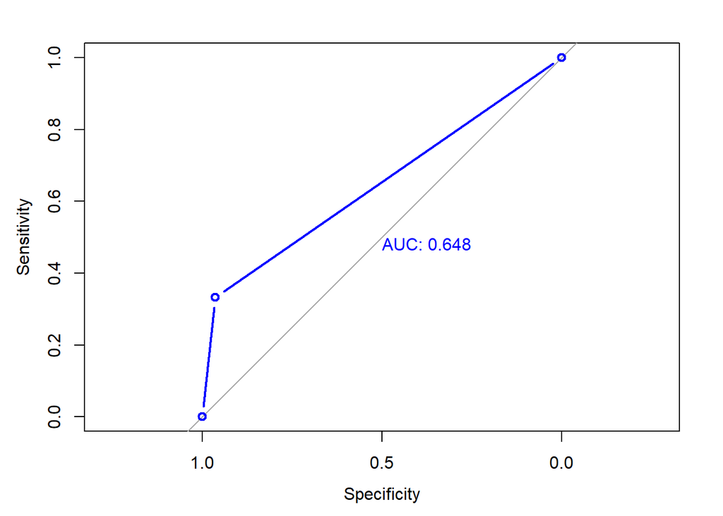

```r
dtree.plot <- plot.roc (as.numeric(DTtest.Data$Attrition), as.numeric(dtree.prd),lwd=2, type="b", print.auc=TRUE, col ="blue")
```

not very nice result! Accuracy is 0.8605 where AUC is 0.648 which is better than SVM Always we can not get better result from RF instead of DTree, but here it is a nice result.

## Exterme Gradient Boost

```r
set.seed(123)
xgbData <- attrition
indexes <- sample(1:nrow(xgbData), size=0.8*nrow(xgbData))
XGBtrain.Data <- xgbData[indexes,]
XGBtest.Data <- xgbData[-indexes,]

formula = Attrition~.
fitControl <- trainControl(method="cv", number = 3,classProbs = TRUE )
xgbGrid <- expand.grid(nrounds = 50,
                       max_depth = 12,
                       eta = .03,
                       gamma = 0.01,
                       colsample_bytree = .7,
                       min_child_weight = 1,
                       subsample = 0.9
)
```

```r
XGB.model <- train(formula, data = XGBtrain.Data,
                  method = "xgbTree"
                  ,trControl = fitControl
                  , verbose=0
                  , maximize=FALSE
                  ,tuneGrid = xgbGrid
)
```

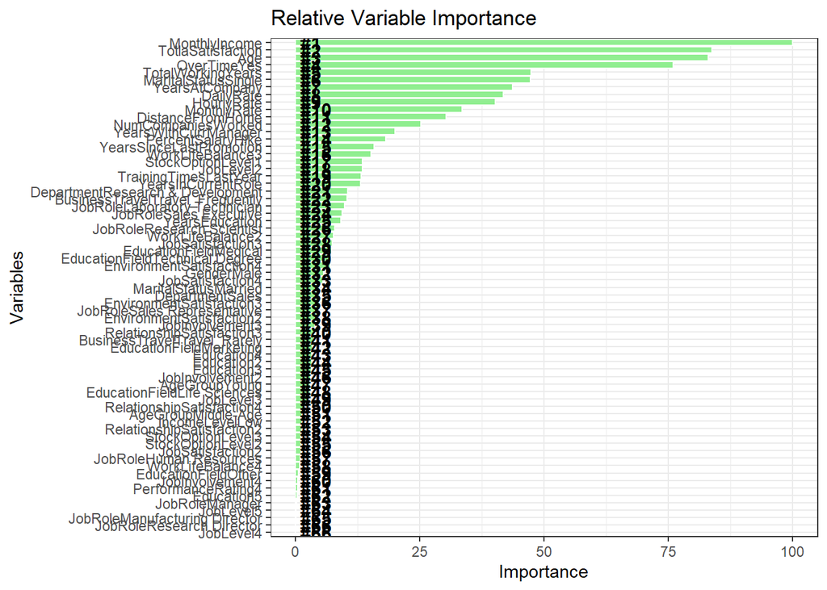

```r
importance <- varImp(XGB.model)
varImportance <- data.frame(Variables = row.names(importance[[1]]),
                            Importance = round(importance[[1]]$Overall,2))
# Create a rank variable based on importance of variables
rankImportance <- varImportance %>%
        mutate(Rank = paste0('#',dense_rank(desc(Importance))))
ggplot(rankImportance, aes(x = reorder(Variables, Importance),
                           y = Importance)) +
        geom_bar(stat='identity',colour="white", fill = "lightgreen") +
        geom_text(aes(x = Variables, y = 1, label = Rank),
                  hjust=0, vjust=.5, size = 4, colour = 'black',
                  fontface = 'bold') +
        labs(x = 'Variables', title = 'Relative Variable Importance') +
        coord_flip() +
        theme_bw()
```

```r
XGB.prd <- predict(XGB.model,XGBtest.Data)
confusionMatrix(XGB.prd, XGBtest.Data$Attrition)
```

```
## Confusion Matrix and Statistics
##
##           Reference
## Prediction  No Yes
##        No  244  36
##        Yes   2  12
##
##                Accuracy : 0.8707
##                  95% CI : (0.8269, 0.9069)
##     No Information Rate : 0.8367
##     P-Value [Acc > NIR] : 0.06374
##
##                   Kappa : 0.3383
##
##  Mcnemar's Test P-Value : 8.636e-08
##
##             Sensitivity : 0.9919
##             Specificity : 0.2500
##          Pos Pred Value : 0.8714
##          Neg Pred Value : 0.8571
##              Prevalence : 0.8367
##          Detection Rate : 0.8299
##    Detection Prevalence : 0.9524
##       Balanced Accuracy : 0.6209
##
##        'Positive' Class : No
##
```

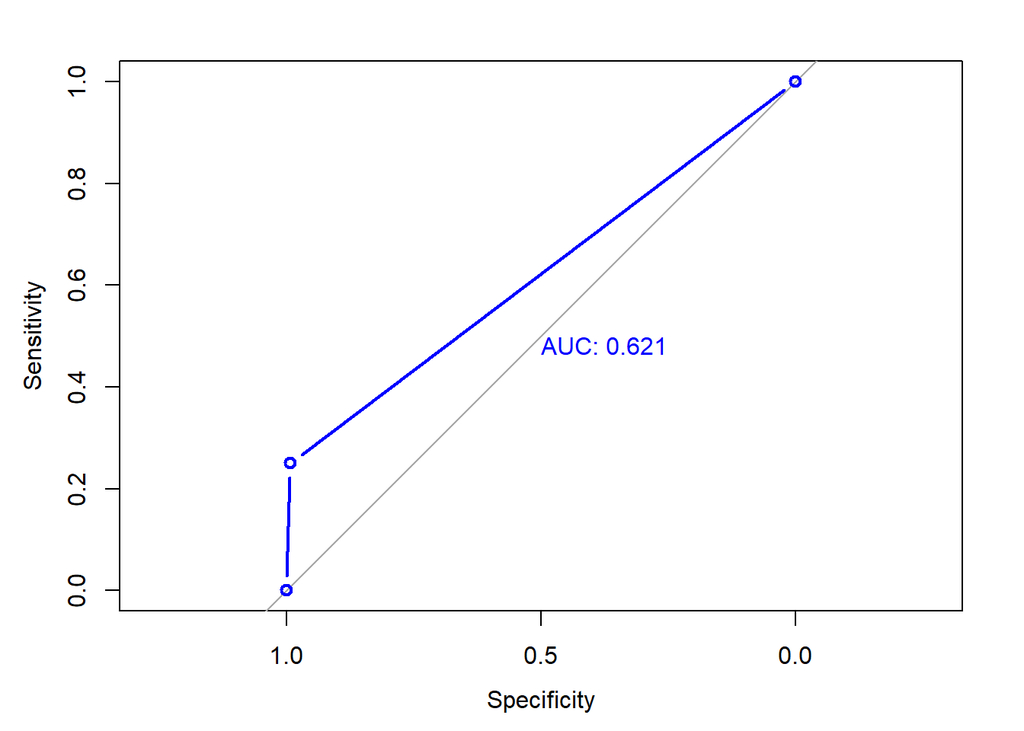

```r
XGB.plot <- plot.roc (as.numeric(XGBtest.Data$Attrition), as.numeric(XGB.prd),lwd=2, type="b", print.auc=TRUE,col ="blue")
```

## Solving Unbalanced data problem

As we mentioned before there is unbalanced problem in class lable. There are some approaches to solve the problem. here we use SMOT method.

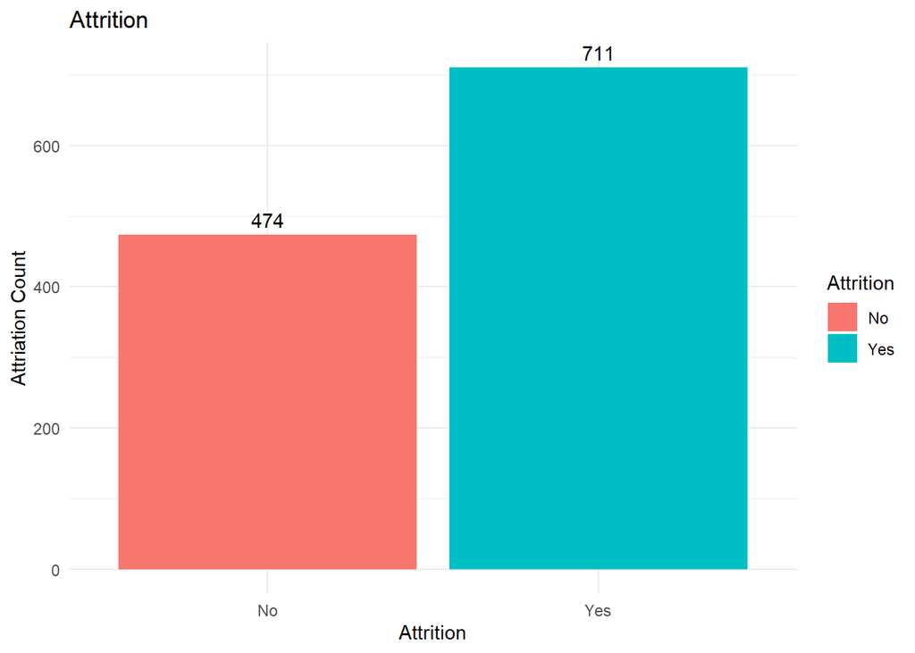

```r
Classcount = table(attrition$Attrition)
# Over Sampling
over = ( (0.6 * max(Classcount)) - min(Classcount) ) / min(Classcount)
# Under Sampling
under = (0.4 * max(Classcount)) / (min(Classcount) * over)

over = round(over, 1) * 100
under = round(under, 1) * 100
#Generate the balanced data set

BalancedData = SMOTE(Attrition~., attrition, perc.over = over, k = 5, perc.under = under)
# let check the output of the Balancing
BalancedData %>%
        group_by(Attrition) %>%
        tally() %>%
        ggplot(aes(x = Attrition, y = n,fill=Attrition)) +
        geom_bar(stat = "identity") +
        theme_minimal()+
        labs(x="Attrition", y="Attriation Count")+
        ggtitle("Attrition")+
        geom_text(aes(label = n), vjust = -0.5, position = position_dodge(0.9))
```

## Let’s try XGBoost with the Balanced Data

```r
set.seed(153)
xgbData <- BalancedData
indexes = sample(1:nrow(xgbData), size=0.8*nrow(xgbData))
BLtrain.Data <- xgbData[indexes,]
BLtest.Data <- xgbData[-indexes,]

formula = Attrition~.
fitControl <- trainControl(method="cv", number = 3,classProbs = TRUE )
xgbGrid <- expand.grid(nrounds = 500,
                       max_depth = 20,
                       eta = .03,
                       gamma = 0.01,
                       colsample_bytree = .7,
                       min_child_weight = 1,
                       subsample = 0.9
)

XGB.model = train(formula, data = BLtrain.Data,
                  method = "xgbTree"
                  ,trControl = fitControl
                  , verbose=0
                  , maximize=FALSE
                  ,tuneGrid = xgbGrid
                  ,na.action = na.pass
)
```

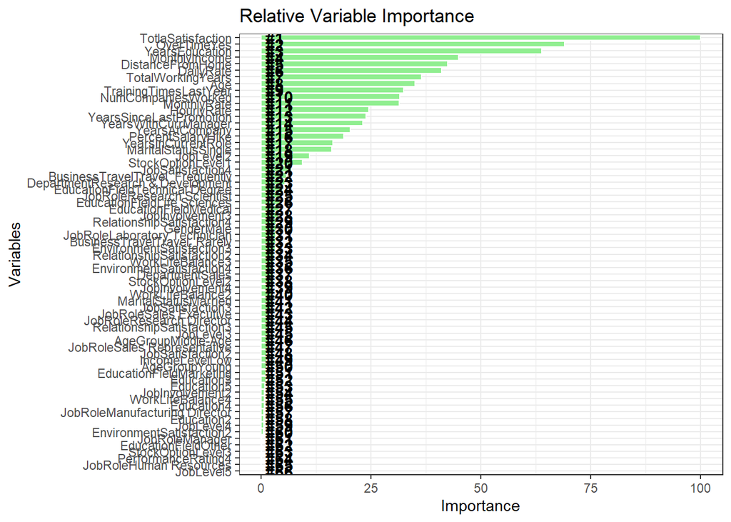

```r
importance <- varImp(XGB.model)
varImportance <- data.frame(Variables = row.names(importance[[1]]),
                            Importance = round(importance[[1]]$Overall,2))
# Create a rank variable based on importance
rankImportance <- varImportance %>%
        mutate(Rank = paste0('#',dense_rank(desc(Importance))))
ggplot(rankImportance, aes(x = reorder(Variables, Importance),
                           y = Importance)) +
        geom_bar(stat='identity',colour="white", fill = "lightgreen") +
        geom_text(aes(x = Variables, y = 1, label = Rank),
                  hjust=0, vjust=.5, size = 4, colour = 'black',
                  fontface = 'bold') +
        labs(x = 'Variables', title = 'Relative Variable Importance') +
        coord_flip() +
        theme_bw()
```

```r
NewXGB.prd <- predict(XGB.model,BLtest.Data)
confusionMatrix(NewXGB.prd, BLtest.Data$Attrition)
```

```
## Confusion Matrix and Statistics
##
##           Reference
## Prediction  No Yes
##        No   81  12
##        Yes  10 134
##
##                Accuracy : 0.9072
##                  95% CI : (0.8628, 0.9409)
##     No Information Rate : 0.616
##     P-Value [Acc > NIR] : <2e-16
##
##                   Kappa : 0.8046
##
##  Mcnemar's Test P-Value : 0.8312
##
##             Sensitivity : 0.8901
##             Specificity : 0.9178
##          Pos Pred Value : 0.8710
##          Neg Pred Value : 0.9306
##              Prevalence : 0.3840
##          Detection Rate : 0.3418
##    Detection Prevalence : 0.3924
##       Balanced Accuracy : 0.9040
##
##        'Positive' Class : No
##
```

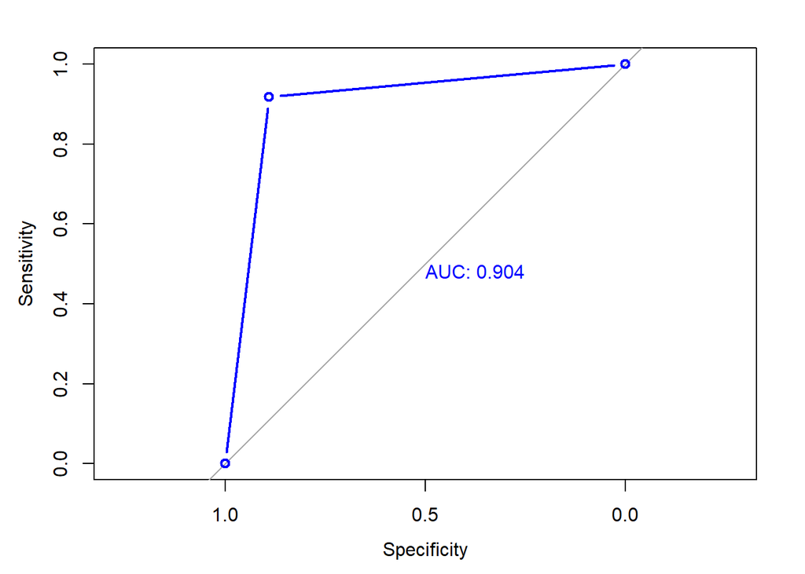

```r
XGB.plot <- plot.roc (as.numeric(BLtest.Data$Attrition), as.numeric(NewXGB.prd),lwd=2, type="b", print.auc=TRUE, col ="blue")
```